# animint tutorial

2015-02-21

## Introduction

This tutorial demonstrates [**animint**](https://github.com/tdhock/animint) – an `R` package for converting [**ggplot2**](http://cran.r-project.org/web/packages/ggplot2/index.html) plots into web-based interactive visualizations.

## Viewing, sharing & embedding animint plots

Suppose we have a basic **ggplot2** plot:

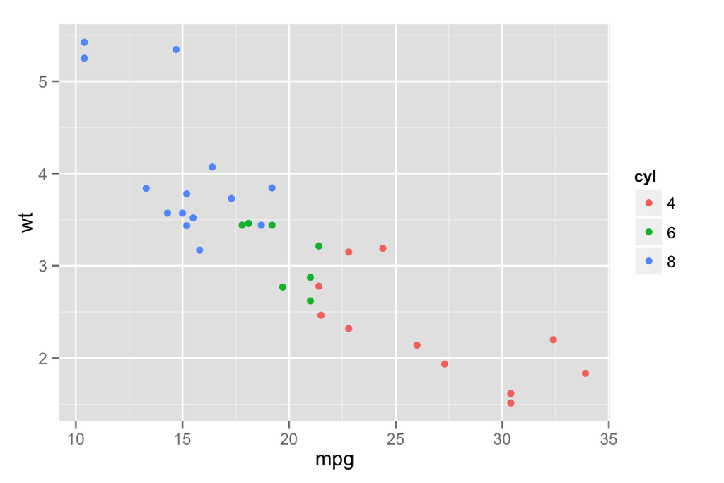

```r
library("ggplot2")
mtcars$cyl <- as.factor(mtcars$cyl)
p <- ggplot() + geom_point(data = mtcars,
    aes(x = mpg, y = wt, colour = cyl))
p
```

### Local viewing

The `animint2dir()` function is most useful for local development and quickly iterating your **animint** plots. This function compiles a list of ggplot objects (and a list of other options), [compiles them](https://github.com/tdhock/animint/wiki/Compiler-details), and write a set of files to a directory. Here we write those files to the “simple” directory.

```r
library("animint")
animint2dir(list(plot = p), out.dir = "simple", open.browser = FALSE)
```

To view the result, you’ll probably want to start a local [file server](http://en.wikipedia.org/wiki/File_server) in the “simple” directory. This can be done easily from the `R` console with the [**servr**](http://cran.r-project.org/web/packages/servr/index.html) package:

```r
servr::httd("simple") # press ESC to stop the server & resume R session
```

### Embedding animint plots in knitr/rmarkdown

You can simply add a class of “animint” to a list ggplot objects in a .Rmd file to embed an animint plot in your document (of course, this will only work if the output file is HTML).

```r
structure(list(plot = p), class = "animint")
```

```r
animint2dir(list(plot = p))
```

## The grammar of graphics in a nutshell

**ggplot2** is an implementation of the [grammar of graphics](http://www.amazon.com/The-Grammar-Graphics-Statistics-Computing/dp/0387245448) which adds the ability to create [layered graphics](http://vita.had.co.nz/papers/layered-grammar.html). A layer consists of five components: Data, Aesthetics, Statistics, Geometry, and Positional Adjustment. The figure below shows how the components fit together to make up a layer. To keep the illustration simple, the graphic in this example is composed of just one layer, but **ggplot2** (and **animint**) allows for multiple layers on a single plot.

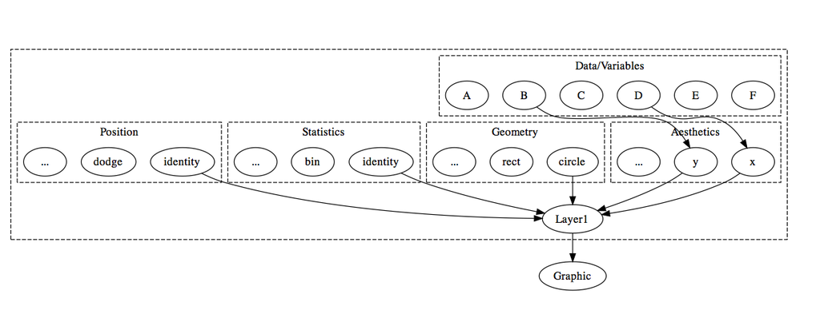

### Adding interactivity with clickSelects & showSelected aesthetics

**animint** understands two aesthetics in addition to the usual ggplot2 aesthetics: `clickSelects` and `showSelected`:

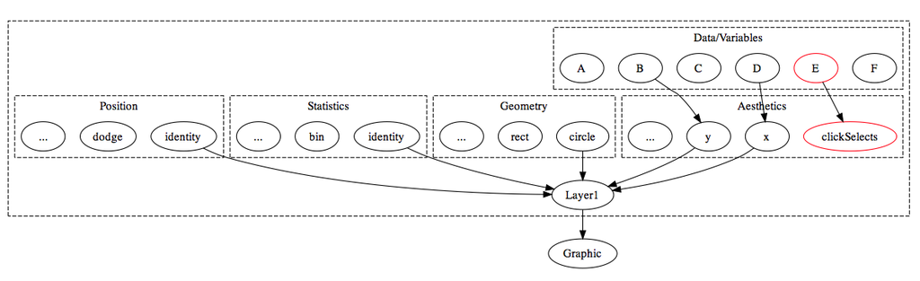

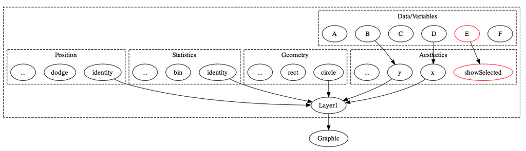

This allows animint to show/hide subsets of data (`showSelected`) according to the current selection (`clickSelects`). For (an overly simplified) example, let’s continue with the `mtcars` example:

```r
p1 <- ggplot() + theme(legend.position = "none") +
  geom_point(data = mtcars,
    aes(x = mpg, y = wt, colour = cyl, clickSelects = cyl))
p2 <- ggplot() +
  geom_point(data = mtcars,
    aes(x = mpg, y = wt, colour = cyl, showSelected = cyl))
p_list <- list(plot1 = p1, plot2 = p2)
structure(p_list, class = "animint")
```